# An inquiry into hotel cancellation data

A summary of the main results :

[output not shown]

```
<class 'pandas.core.frame.DataFrame'>
RangeIndex: 5000 entries, 0 to 4999
Data columns (total 20 columns):
 #   Column                       Non-Null Count  Dtype
---  ------                       --------------  -----
 0   hotel                        5000 non-null   object
 1   arrival_date_month           5000 non-null   object
 2   arrival_date_week_number     5000 non-null   int64
 3   arrival_date_day_of_month    5000 non-null   int64
 4   stays_in_weekend_nights      5000 non-null   int64
 5   stays_in_week_nights         5000 non-null   int64
 6   adults                       5000 non-null   int64
 7   meal                         5000 non-null   object
 8   country                      5000 non-null   object
 9   market_segment               5000 non-null   object
 10  distribution_channel         5000 non-null   object
 11  reserved_room_type           5000 non-null   object
 12  assigned_room_type           5000 non-null   object
 13  booking_changes              5000 non-null   int64
 14  deposit_type                 5000 non-null   object
 15  customer_type                5000 non-null   object
 16  adr                          5000 non-null   float64
 17  required_car_parking_spaces  5000 non-null   int64
 18  total_of_special_requests    5000 non-null   int64
 19  canceled                     5000 non-null   int64
dtypes: float64(1), int64(9), object(10)
memory usage: 781.4+ KB
```

The proportion of cancellations is given by

```
0.3652
```

## How are the variables distributed in the dataset

### The overall distribution of the numerical variables

|  | count | mean | std | min | 25% | 50% | 75% | max |
| --- | --- | --- | --- | --- | --- | --- | --- | --- |
| arrival_date_week_number | 5000.0 | 27.061800 | 13.531585 | 1.0 | 16.0 | 27.0 | 38.0 | 53.0 |
| arrival_date_day_of_month | 5000.0 | 15.708600 | 8.791311 | 1.0 | 8.0 | 16.0 | 23.0 | 31.0 |
| stays_in_weekend_nights | 5000.0 | 0.906600 | 0.971012 | 0.0 | 0.0 | 1.0 | 2.0 | 8.0 |
| stays_in_week_nights | 5000.0 | 2.489800 | 1.826955 | 0.0 | 1.0 | 2.0 | 3.0 | 20.0 |
| adults | 5000.0 | 1.863000 | 0.482781 | 0.0 | 2.0 | 2.0 | 2.0 | 4.0 |
| booking_changes | 5000.0 | 0.219000 | 0.673446 | 0.0 | 0.0 | 0.0 | 0.0 | 18.0 |
| adr | 5000.0 | 102.669692 | 48.879693 | 0.0 | 70.0 | 94.5 | 126.0 | 382.0 |
| required_car_parking_spaces | 5000.0 | 0.065000 | 0.248168 | 0.0 | 0.0 | 0.0 | 0.0 | 2.0 |
| total_of_special_requests | 5000.0 | 0.574200 | 0.793864 | 0.0 | 0.0 | 0.0 | 1.0 | 5.0 |
| canceled | 5000.0 | 0.365200 | 0.481534 | 0.0 | 0.0 | 0.0 | 1.0 | 1.0 |

### The distribution of some interesting categorical variables : travel agencies capture most of the bookings, Bed and Breakfast are particuarly demanded

For some variables, and especially the categorical ones, we can rely on counting to get sense of their occurence in the dataset. For example, the table below gives the counts of the market segments according to the operator through which the customer makes her booking. In this example, we see that customers usually go through online travel agencies to book a stay. In fact, travel agencies and tour operators stand as the main distribution channel of bookings in the dataset.

```
Online TA        0.4694
Offline TA/TO    0.1972
Groups           0.1752
Direct           0.1096
Corporate        0.0408
Complementary    0.0058
Aviation         0.0020
Name: market_segment, dtype: float64
```

```
TA/TO        0.8130
Direct       0.1326
Corporate    0.0528
GDS          0.0016
Name: distribution_channel, dtype: float64
```

```
BB           0.7614
HB           0.1310
SC           0.0876
Undefined    0.0120
FB           0.0080
Name: meal, dtype: float64
```

```
Transient          0.7450
Transient-Party    0.2166
Contract           0.0342
Group              0.0042
Name: customer_type, dtype: float64
```

### A figure is worth a thousand word: Distributions through plots

We can also capture these features graphically by plotting the densities of the numerical variables and the counts of the categorical variables. As said before, we see graphically that the numerical variables are indeed skewed to the right. Weekend stays are concentrated around none and two a year, while week stays go up to five and rarely more. The average daily rate is around 90 dollars. The market is most dominated by online travel agencies and, to a less extent, offline travel agencies. Transcient customers represent the bulk of customer type.

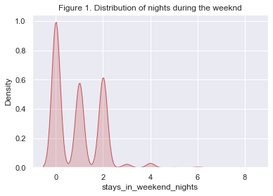

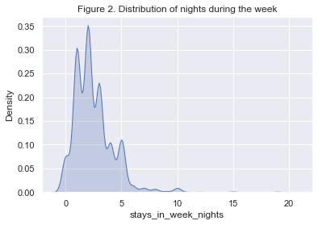

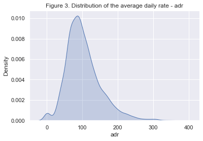

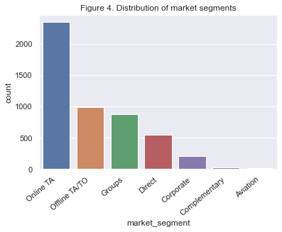

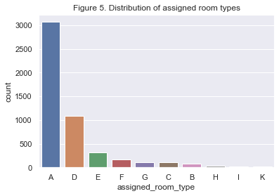

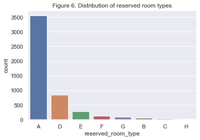

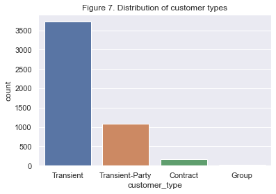

## How do the variables interact with each other ?

### 1. Number of stays by market segements

The tables below give the cross-tabulation of the number of stays according the different market segments available in the dataset. The first observation we can make is that, across all the categories, the customers do not usually make more than two bookings a year for stays during the weekend, while they tend to book more stays during the week (up to 5 stays a year). The latter observation is particularly relevant for direct bookings, group bookings and bookings through an agency or an operator. The figure 8 and 9 below give the densities of stays according to each market segment. Overall, the observation of right tail skewness that is observed across the whole dataset also translates at the granular level.

| market_segment stays_in_weekend_nights | Aviation | Complementary | Corporate | Direct | Groups | Offline TA/TO | Online TA |
| --- | --- | --- | --- | --- | --- | --- | --- |
| 0 | 0.3 | 0.724138 | 0.691176 | 0.481752 | 0.484018 | 0.437120 | 0.395398 |
| 1 | 0.4 | 0.137931 | 0.235294 | 0.244526 | 0.283105 | 0.215010 | 0.270984 |
| 2 | 0.1 | 0.137931 | 0.053922 | 0.239051 | 0.218037 | 0.301217 | 0.312740 |
| 3 | 0.0 | 0.000000 | 0.009804 | 0.025547 | 0.003425 | 0.014199 | 0.008095 |
| 4 | 0.0 | 0.000000 | 0.000000 | 0.009124 | 0.006849 | 0.030426 | 0.010652 |
| 5 | 0.2 | 0.000000 | 0.004902 | 0.000000 | 0.000000 | 0.000000 | 0.000426 |
| 6 | 0.0 | 0.000000 | 0.000000 | 0.000000 | 0.004566 | 0.002028 | 0.001278 |
| 7 | 0.0 | 0.000000 | 0.004902 | 0.000000 | 0.000000 | 0.000000 | 0.000000 |
| 8 | 0.0 | 0.000000 | 0.000000 | 0.000000 | 0.000000 | 0.000000 | 0.000426 |

| market_segment stays_in_week_nights | Aviation | Complementary | Corporate | Direct | Groups | Offline TA/TO | Online TA |
| --- | --- | --- | --- | --- | --- | --- | --- |
| 0 | 0.1 | 0.172414 | 0.137255 | 0.093066 | 0.033105 | 0.040568 | 0.064337 |
| 1 | 0.3 | 0.413793 | 0.495098 | 0.333942 | 0.272831 | 0.192698 | 0.222412 |
| 2 | 0.2 | 0.310345 | 0.166667 | 0.213504 | 0.399543 | 0.325558 | 0.259906 |
| 3 | 0.1 | 0.068966 | 0.112745 | 0.142336 | 0.165525 | 0.199797 | 0.210481 |
| 4 | 0.1 | 0.034483 | 0.029412 | 0.069343 | 0.050228 | 0.069980 | 0.112058 |
| 5 | 0.0 | 0.000000 | 0.029412 | 0.096715 | 0.063927 | 0.111562 | 0.098850 |
| 6 | 0.0 | 0.000000 | 0.004902 | 0.018248 | 0.002283 | 0.011156 | 0.013208 |
| 7 | 0.0 | 0.000000 | 0.004902 | 0.016423 | 0.004566 | 0.008114 | 0.006391 |
| 8 | 0.0 | 0.000000 | 0.000000 | 0.007299 | 0.000000 | 0.013185 | 0.004687 |
| 9 | 0.0 | 0.000000 | 0.004902 | 0.001825 | 0.000000 | 0.004057 | 0.001278 |
| 10 | 0.2 | 0.000000 | 0.004902 | 0.005474 | 0.001142 | 0.020284 | 0.004261 |
| 11 | 0.0 | 0.000000 | 0.004902 | 0.000000 | 0.001142 | 0.000000 | 0.000000 |
| 12 | 0.0 | 0.000000 | 0.000000 | 0.000000 | 0.001142 | 0.001014 | 0.000426 |
| 13 | 0.0 | 0.000000 | 0.000000 | 0.000000 | 0.000000 | 0.001014 | 0.000000 |
| 14 | 0.0 | 0.000000 | 0.000000 | 0.000000 | 0.000000 | 0.000000 | 0.000426 |
| 15 | 0.0 | 0.000000 | 0.004902 | 0.001825 | 0.000000 | 0.001014 | 0.000852 |
| 19 | 0.0 | 0.000000 | 0.000000 | 0.000000 | 0.004566 | 0.000000 | 0.000000 |
| 20 | 0.0 | 0.000000 | 0.000000 | 0.000000 | 0.000000 | 0.000000 | 0.000426 |

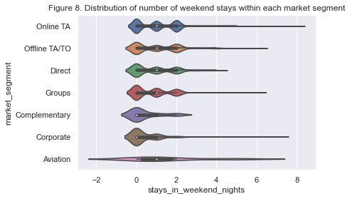

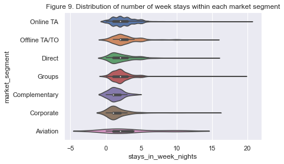

### 2. Number of stays by customer type

We now turn to the interaction between the number of stays and the customer types in the dataset, given by the two tables below. A general observation is that, across all types, most customer have not booked more than twice weekend nights during the year, while they book much more stays (at least five) during the week. It reflects the pattern observed on the other end of the market (supply intermediaries i.e. market segments). Comparing the bookings across categories, we see that contract customer book on average more weekend nights than group or transient customers, relative to each categories' size in the data.

| customer_type stays_in_weekend_nights | Contract | Group | Transient | Transient-Party |
| --- | --- | --- | --- | --- |
| 0 | 0.309942 | 0.380952 | 0.428188 | 0.513389 |
| 1 | 0.245614 | 0.380952 | 0.265503 | 0.228070 |
| 2 | 0.327485 | 0.190476 | 0.280000 | 0.245614 |
| 3 | 0.023392 | 0.047619 | 0.011275 | 0.004617 |
| 4 | 0.093567 | 0.000000 | 0.012617 | 0.002770 |
| 5 | 0.000000 | 0.000000 | 0.000805 | 0.000923 |
| 6 | 0.000000 | 0.000000 | 0.001342 | 0.003693 |
| 7 | 0.000000 | 0.000000 | 0.000000 | 0.000923 |
| 8 | 0.000000 | 0.000000 | 0.000268 | 0.000000 |

| customer_type stays_in_week_nights | Contract | Group | Transient | Transient-Party |
| --- | --- | --- | --- | --- |
| 0 | 0.017544 | 0.142857 | 0.067383 | 0.044321 |
| 1 | 0.187135 | 0.285714 | 0.241074 | 0.289935 |
| 2 | 0.251462 | 0.238095 | 0.278658 | 0.329640 |
| 3 | 0.093567 | 0.095238 | 0.193826 | 0.184672 |
| 4 | 0.099415 | 0.047619 | 0.090201 | 0.062789 |
| 5 | 0.204678 | 0.095238 | 0.092081 | 0.071099 |
| 6 | 0.011696 | 0.000000 | 0.012886 | 0.004617 |
| 7 | 0.017544 | 0.047619 | 0.007517 | 0.004617 |
| 8 | 0.040936 | 0.047619 | 0.005101 | 0.000923 |
| 9 | 0.005848 | 0.000000 | 0.001879 | 0.000923 |
| 10 | 0.064327 | 0.000000 | 0.006980 | 0.000000 |
| 11 | 0.005848 | 0.000000 | 0.000000 | 0.000923 |
| 12 | 0.000000 | 0.000000 | 0.000537 | 0.000923 |
| 13 | 0.000000 | 0.000000 | 0.000268 | 0.000000 |
| 14 | 0.000000 | 0.000000 | 0.000268 | 0.000000 |
| 15 | 0.000000 | 0.000000 | 0.001074 | 0.000923 |
| 19 | 0.000000 | 0.000000 | 0.000000 | 0.003693 |
| 20 | 0.000000 | 0.000000 | 0.000268 | 0.000000 |

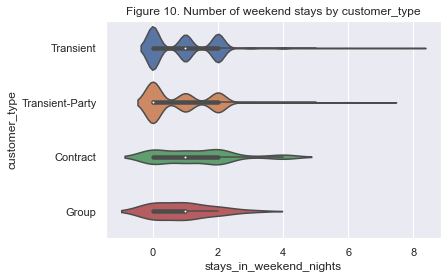

[figure not shown]

### 3. Number of stays by hotel type

We look at the number of stays by hotel type. We rely this time on a simple graphical representation (figures 12 and 13 below). In accodance with the overall pattern in the dataset, we see that resort hotels are more represented across bookings, whatever their type. Also, as one would expect, they match the patterns observed when considering stays by supply or demand determinants, with the notable exception that most city hotels are booked for a unique weekend stay per year.

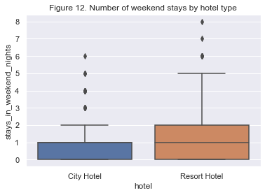

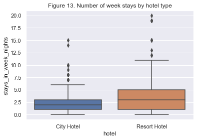

### 4. Number of stays by arrival month of the year

A general observation is that stays are distributed almost uniformly across the year. Week stays are however more often during the months of August and July, while weekend stays are on average less in January, February and November.

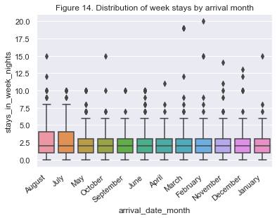

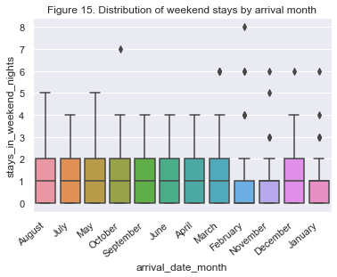

### 5. Customer types by reserved and assigned rooms, rooms by meal

| reserved_room_type customer_type | A | B | C | D | E | F | G | H |
| --- | --- | --- | --- | --- | --- | --- | --- | --- |
| Contract | 122 | 0 | 1 | 36 | 5 | 7 | 0 | 0 |
| Group | 17 | 0 | 0 | 2 | 2 | 0 | 0 | 0 |
| Transient | 2481 | 33 | 38 | 722 | 221 | 118 | 85 | 27 |
| Transient-Party | 931 | 19 | 6 | 76 | 43 | 3 | 5 | 0 |

| assigned_room_type customer_type | A | B | C | D | E | F | G | H | I | K |
| --- | --- | --- | --- | --- | --- | --- | --- | --- | --- | --- |
| Contract | 109 | 2 | 4 | 37 | 7 | 10 | 1 | 0 | 1 | 0 |
| Group | 13 | 0 | 0 | 3 | 2 | 1 | 2 | 0 | 0 | 0 |
| Transient | 2173 | 41 | 81 | 884 | 251 | 140 | 103 | 33 | 9 | 10 |
| Transient-Party | 773 | 34 | 22 | 162 | 59 | 13 | 7 | 2 | 7 | 4 |

| reserved_room_type meal | A | B | C | D | E | F | G | H |
| --- | --- | --- | --- | --- | --- | --- | --- | --- |
| BB | 2627 | 50 | 33 | 705 | 192 | 100 | 79 | 21 |
| FB | 33 | 0 | 2 | 3 | 2 | 0 | 0 | 0 |
| HB | 413 | 1 | 9 | 122 | 72 | 22 | 10 | 6 |
| SC | 427 | 1 | 0 | 2 | 3 | 4 | 1 | 0 |
| Undefined | 51 | 0 | 1 | 4 | 2 | 2 | 0 | 0 |

| arrival_date_month room_changed | April | August | December | February | January | July | June | March | May | November | October | September |
| --- | --- | --- | --- | --- | --- | --- | --- | --- | --- | --- | --- | --- |
| False | 413 | 542 | 213 | 275 | 205 | 480 | 423 | 368 | 448 | 218 | 405 | 393 |
| True | 39 | 43 | 51 | 53 | 46 | 40 | 39 | 55 | 60 | 46 | 68 | 77 |

## How do the variables interact with the target ?

We know move into studying the relationship between the variables of the dataset and the variable of interest, "canceled", which takes 1 if a booking is canceled and zero otherwise. We will proceed in the same way as the previous section, cross-tabulating the target variable with the other variables. The objective is to narrow the scope of the analysis to the most fundamental determinants of cancellations in the dataset.

### 1. Cancellation by customer types

As shown in the table below, which gives the proportions of canceled bookings, for each customer type, we observe that cancellations are most associated with Transient customers, followed by contract customers. Also, given that Transient customers represent more than 74% of the customer, then it is more likely that they are the ones responsible of the large part of the cancellations. To verify this, we change the sense of the cross-tabulation in the second table, where we know now look at the respective contribution to cancellation of each customer's type. It appears that 83% of the cancellation in the dataset are indeed due to Transient customers.

| customer_type canceled | Contract | Group | Transient | Transient-Party | All |
| --- | --- | --- | --- | --- | --- |
| 0 | 0.672515 | 0.904762 | 0.591946 | 0.771006 | 0.6348 |
| 1 | 0.327485 | 0.095238 | 0.408054 | 0.228994 | 0.3652 |

| canceled customer_type | 0 | 1 | All |
| --- | --- | --- | --- |
| Contract | 0.036232 | 0.030668 | 0.0342 |
| Group | 0.005986 | 0.001095 | 0.0042 |
| Transient | 0.694707 | 0.832421 | 0.7450 |
| Transient-Party | 0.263075 | 0.135816 | 0.2166 |

### 2. Cancellation by market segment

We know turn to the interaction between cancellations and market segment to identify the component of the supply side of the market that suffers most from the cancellations. In the first table below, we observe that Groups are over more likely be subject to a cancellation than are the other market segment. They reprsent in fact around 28% of cancellation in the dataset. This is still less than the figure for Online Travel Agencies and Tour operators, but, relative to the size of each group, the likelihood of cancellation is more important when it comes to the former.

| canceled market_segment | 0 | 1 |
| --- | --- | --- |
| Aviation | 0.900000 | 0.100000 |
| Complementary | 0.827586 | 0.172414 |
| Corporate | 0.818627 | 0.181373 |
| Direct | 0.868613 | 0.131387 |
| Groups | 0.432648 | 0.567352 |
| Offline TA/TO | 0.652130 | 0.347870 |
| Online TA | 0.628888 | 0.371112 |
| All | 0.634800 | 0.365200 |

| canceled market_segment | 0 | 1 | All |
| --- | --- | --- | --- |
| Aviation | 0.002836 | 0.000548 | 0.0020 |
| Complementary | 0.007561 | 0.002738 | 0.0058 |
| Corporate | 0.052615 | 0.020263 | 0.0408 |
| Direct | 0.149968 | 0.039430 | 0.1096 |
| Groups | 0.119408 | 0.272180 | 0.1752 |
| Offline TA/TO | 0.202583 | 0.187842 | 0.1972 |
| Online TA | 0.465028 | 0.476999 | 0.4694 |

### 3. Supply intermediaries meet demand : a more granular look into customer types and market segment

As it appears in the previous section, customer types and market segment stand as two important characteristics that determine the likelihood of cancellation. In this section, we will take a more granular approach to study the specific effect of each variable on cancellation and their interaction with other interesting variables in the dataset.

First, we look at the interactions between the two characteristics to understand the underlying mechanism behind some of the previous results. In the cross-tabulation below, it appears that one relevant, and a bit obvious, explanation of the importance of market segments in explaining cancellation is that the transient customers, which represent the essentiel part of the dataset are over-represented in every segment of the market and have a higher likelihood of cancellation as shown above.

| customer_type market_segment | Contract | Group | Transient | Transient-Party |
| --- | --- | --- | --- | --- |
| Aviation | 0.000000 | 0.000000 | 1.000000 | 0.000000 |
| Complementary | 0.000000 | 0.000000 | 0.931034 | 0.068966 |
| Corporate | 0.009804 | 0.009804 | 0.647059 | 0.333333 |
| Direct | 0.000000 | 0.007299 | 0.890511 | 0.102190 |
| Groups | 0.037671 | 0.002283 | 0.396119 | 0.563927 |
| Offline TA/TO | 0.073022 | 0.006085 | 0.602434 | 0.318458 |
| Online TA | 0.027269 | 0.002983 | 0.906263 | 0.063485 |
| All | 0.034200 | 0.004200 | 0.745000 | 0.216600 |

#### 1. Scoring the impact of transcient customer on the hotels

We focus in this subsection on giving a metric to assess the impact of each customer type on the hotel. For that purpose, we group the data by customer types and market segemt and look at the rate of cancellation within each cross-category, whenever it is relevant and available. The table below gives the results. We obseve that grouping by customer and market segment, contract customers who booked by groups are very likely to cancel (93%), as well as transient customers who booked by groups (96%). By looking at the sum of cancellations, we note that they account for an important part.

| market_segment customer_type | Aviation | Complementary | Corporate | Direct | Groups | Offline TA/TO | Online TA |
| --- | --- | --- | --- | --- | --- | --- | --- |
| Contract | NaN | NaN | 0.000000 | NaN | 0.939394 | 0.125000 | 0.250000 |
| Group | NaN | NaN | 0.000000 | 0.250000 | 0.000000 | 0.166667 | 0.000000 |
| Transient | 0.1 | 0.185185 | 0.181818 | 0.131148 | 0.962536 | 0.424242 | 0.394922 |
| Transient-Party | NaN | 0.000000 | 0.191176 | 0.125000 | 0.267206 | 0.257962 | 0.100671 |

In the continuity of the previous table, we try to quantify the impact of customer types on hotel through a new metric that takes into account the rate of cancellation as well as the number of cancellation. It is constructed as follows

$$ canc\_c\_m\_piv4 = canc\_c\_m\_piv2 - 2\times canc\_c\_m\_piv3 $$

where $canc\_c\_m\_piv2$ corresponds to the count of cancellations within each subgroups and $canc\_c\_m\_piv3$ to sum within each subgroups. The more negative is the metric the more negative is the effect on the hotels.

The table below gives the results. We see that transcient customer that book through groups and contract customers tha book through the same mean are the ones that affect most negatively hotels, with respective scores of -321 and -29.

| market_segment customer_type | Aviation | Complementary | Corporate | Direct | Groups | Offline TA/TO | Online TA |
| --- | --- | --- | --- | --- | --- | --- | --- |
| Contract | NaN | NaN | 2.0 | NaN | -29.0 | 54.0 | 32.0 |
| Group | NaN | NaN | 2.0 | 2.0 | 2.0 | 4.0 | 7.0 |
| Transient | 8.0 | 17.0 | 84.0 | 360.0 | -321.0 | 90.0 | 447.0 |
| Transient-Party | NaN | 2.0 | 42.0 | 42.0 | 230.0 | 152.0 | 119.0 |

#### 2. A focus on groups

We now turn our interest into the groups, which appeared to be very relevant for cancellation in the previous section. For that matter, we create a subset of the bookings dataset that only keeps observations where the market segment is Groups.

Then, we look at the distribution of some variables within that subset. Overall, it appears that it captures the main features of the full dataset. Indeed, most of the variablesstill have a right-skewed distribution. City hotels are the most represented type of hotels. However, it appears that Transcient party customers are more represented within Groups.

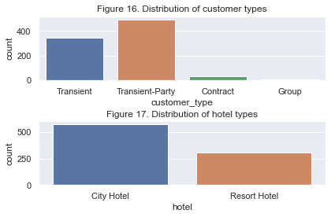

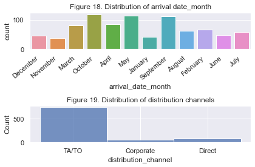

```
PRT    0.671233
GBR    0.078767
ESP    0.063927
DEU    0.037671
FRA    0.028539
AUT    0.018265
ISR    0.015982
CN     0.015982
IRL    0.012557
ITA    0.007991
BEL    0.006849
SWE    0.005708
AUS    0.005708
USA    0.004566
POL    0.003425
RUS    0.003425
MEX    0.002283
NLD    0.002283
EST    0.001142
MNE    0.001142
EGY    0.001142
CHN    0.001142
UKR    0.001142
HUN    0.001142
KNA    0.001142
LVA    0.001142
CAF    0.001142
HRV    0.001142
CHE    0.001142
CYP    0.001142
DNK    0.001142
Name: country, dtype: float64
```

| country customer_type | AUS | AUT | BEL | CAF | CHE | CHN | CN | CYP | DEU | DNK | ... | LVA | MEX | MNE | NLD | POL | PRT | RUS | SWE | UKR | USA |
| --- | --- | --- | --- | --- | --- | --- | --- | --- | --- | --- | --- | --- | --- | --- | --- | --- | --- | --- | --- | --- | --- |
| Contract | 0.000000 | 0.000000 | 0.000000 | 0.000000 | 0.000000 | 0.000000 | 0.00000 | 0.000000 | 0.060606 | 0.000000 | ... | 0.000000 | 0.000000 | 0.000000 | 0.000000 | 0.000000 | 0.939394 | 0.000000 | 0.000000 | 0.000000 | 0.000000 |
| Group | 0.000000 | 0.000000 | 0.000000 | 0.000000 | 0.000000 | 0.000000 | 0.00000 | 0.000000 | 0.000000 | 0.000000 | ... | 0.000000 | 0.000000 | 0.000000 | 0.000000 | 0.000000 | 0.000000 | 0.000000 | 0.000000 | 0.000000 | 0.000000 |
| Transient | 0.000000 | 0.000000 | 0.005764 | 0.000000 | 0.000000 | 0.000000 | 0.00000 | 0.000000 | 0.000000 | 0.000000 | ... | 0.002882 | 0.000000 | 0.000000 | 0.000000 | 0.002882 | 0.933718 | 0.002882 | 0.000000 | 0.000000 | 0.000000 |
| Transient-Party | 0.010121 | 0.032389 | 0.008097 | 0.002024 | 0.002024 | 0.002024 | 0.02834 | 0.002024 | 0.062753 | 0.002024 | ... | 0.000000 | 0.004049 | 0.002024 | 0.004049 | 0.004049 | 0.471660 | 0.004049 | 0.010121 | 0.002024 | 0.008097 |

4 rows × 31 columns

Finally, we look at the interaction between the country of origin and the target variable to see whether there is a particular pattern for the country that is most represented in Groups. We find indeed that guests of Portugese origin have a higher rate of cancellation, much higher than that of the overall dataset.

|  | country | canceled mean | canceled count |
| --- | --- | --- | --- |
| 0 | False | 0.065972 | 288 |
| 1 | True | 0.812925 | 588 |

|  | country | canceled mean | canceled count |
| --- | --- | --- | --- |
| 0 | False | 0.226287 | 2952 |
| 1 | True | 0.565430 | 2048 |

#### 3. Transcient and contract customers within groups

First, we look at some properties of this types of customers. First, we compare the densities of stays in this subset as compared to overall dataset. The distribution have the same shape across both ensembles. However, 2 nights week stays are more present in the subset of Transcient customers within groups. This is indeed confirmed by the countplots. Transcient customers appear to favor week stays to weekend stays during the year. We do the same for contract customers and it appears that distribution in Groups is smoother and looks like a Gaussian with a large right tail, centered around two days week stays.

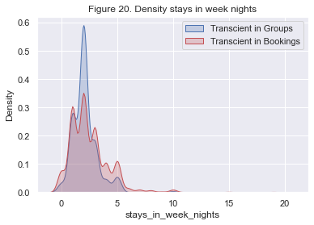

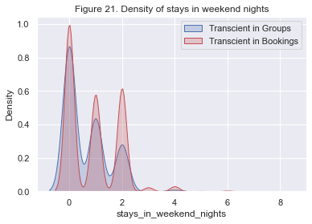

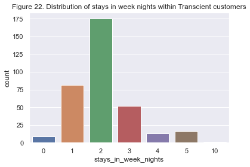

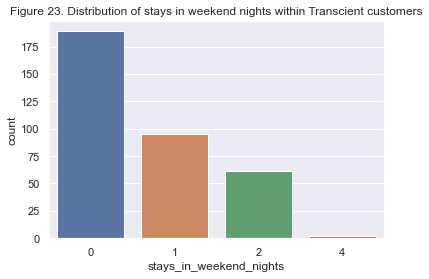

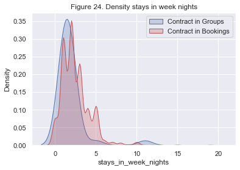

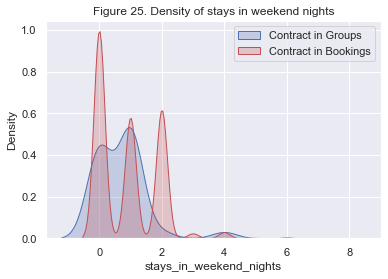

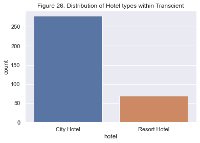

We now turn to cancellation patterns across the two customers type. The cross-tabulations below give the interaction between each customer type within Groups and the target variable. Among the Contract type, we find that all customers that come from Portugal have canceled their bookings during the year. Portuguese Transcient customers have account for 95% of the cancellation in this type subgroup.

| canceled country | 0 | 1 |
| --- | --- | --- |
| DEU | 1.0 | 0.0 |
| PRT | 0.0 | 1.0 |

| country canceled | BEL | ESP | EST | GBR | HRV | LVA | POL | PRT | RUS |
| --- | --- | --- | --- | --- | --- | --- | --- | --- | --- |
| 0 | 0.076923 | 0.076923 | 0.076923 | 0.076923 | 0.076923 | 0.076923 | 0.000000 | 0.461538 | 0.076923 |
| 1 | 0.002994 | 0.032934 | 0.000000 | 0.008982 | 0.000000 | 0.000000 | 0.002994 | 0.952096 | 0.000000 |

According to hotel types, it appears that both types have strong likelihood to face a cancellation but it is slighlty higher for city hotels, as show in the following pattern.

| canceled hotel | 0 | 1 |
| --- | --- | --- |
| City Hotel | 0.021583 | 0.978417 |
| Resort Hotel | 0.101449 | 0.898551 |

We now consider the interaction with Groups between the requirement for a non-refundable deposit for a booking and the target variable. The table below gives the crosstabulation for these two instances. Suprisingly, we find that bookings where a non-refundable deposit is required belong all to the canceled category. This result seems a bit puzzling as one would expect a deposit-scheme to be a way to guarantee the commitment of the customer. This pattern does not only concern the transcient customer but also the contract customer using Groups as a means of booking, but also over the whole dataset, as shown in the subsequent tables.

| canceled deposit_type | 0 | 1 |
| --- | --- | --- |
| No Deposit | 0.619048 | 0.380952 |
| Non Refund | 0.000000 | 1.000000 |

| canceled deposit_type | 0 | 1 |
| --- | --- | --- |
| No Deposit | 0.25 | 0.75 |
| Non Refund | 0.00 | 1.00 |

| canceled deposit_type | 0 | 1 |
| --- | --- | --- |
| No Deposit | 0.720655 | 0.279345 |
| Non Refund | 0.003333 | 0.996667 |
| Refundable | 1.000000 | 0.000000 |

To verify the consistency of this pattern, we plot the distribution of observations for the deposit variable within the two subgroups of custmer types as well as within the whole dataset. First, we note that non-refundable deposits represent the majority option, for both customer type, using Groups bookings. This pattern is not generalized in the full dataset, as it appears that customers usually book rooms requiring no deposits. Hence, we are only observing a feature of the subset of the full dataset.

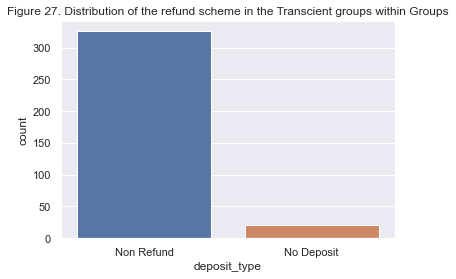

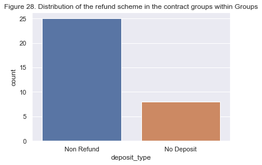

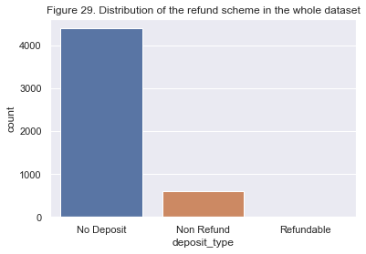

#### 4. Rationalizing the irrational : an explation for the deposit puzzle

| deposit_type country | False | True |
| --- | --- | --- |
| False | 0.666364 | 0.033333 |
| True | 0.333636 | 0.966667 |

|  |  | 0 | 1 | 2 | 3 |
| --- | --- | --- | --- | --- | --- |
| country |  | False | False | True | True |
| deposit_type |  | False | True | False | True |
| canceled | count | 2932 | 20 | 1468 | 580 |

#### 5. Exploring Deposit types

In this part, we will try to identify other variables than could explain the deposit types' pattern. We are interested in finding strong interactions.

We start first by looking at the bookings length, where we interact deposits with stays. As it appears, in the following two tables, customers usually book without a deposit, irrespective of the number of nights they spend in a hotel.

The second dimension we explore is time. We cannot identify any seasonal pattern in the data, whereby hotels requires more deposits. For the most part, hotels ask for no deposits. We then explore distirbution channels and customer types. Again, there is no relevant pattern we can use to infer on deposits.

However, the interaction with market segments seems relevant. Groups and Offline Travel Agencies/Tour Operators ask more often for a deposit than the other market segments. One reason could be the cost of verification related to offline bookings, which induces a risk for the operator. For Groups, besides the Portuguese explanation, another reason could be that the deposit serves as a minimum compensation on cancellation hazard that induces an opportunity cost of not giving the booking to a third part customer.

| stays_in_week_nights deposit_type | 0 | 1 | 2 | 3 | 4 | 5 | 6 | 7 | 8 | 9 | 10 | 11 | 12 | 13 | 14 | 15 | 19 | 20 | All |
| --- | --- | --- | --- | --- | --- | --- | --- | --- | --- | --- | --- | --- | --- | --- | --- | --- | --- | --- | --- |
| No Deposit | 0.947541 | 0.8928 | 0.79903 | 0.872340 | 0.938389 | 0.962801 | 1.0 | 1.0 | 1.0 | 1.0 | 0.972973 | 1.0 | 1.0 | 1.0 | 1.0 | 1.0 | 1.0 | 1.0 | 0.8792 |
| Non Refund | 0.049180 | 0.1064 | 0.20097 | 0.125532 | 0.061611 | 0.037199 | 0.0 | 0.0 | 0.0 | 0.0 | 0.027027 | 0.0 | 0.0 | 0.0 | 0.0 | 0.0 | 0.0 | 0.0 | 0.1200 |
| Refundable | 0.003279 | 0.0008 | 0.00000 | 0.002128 | 0.000000 | 0.000000 | 0.0 | 0.0 | 0.0 | 0.0 | 0.000000 | 0.0 | 0.0 | 0.0 | 0.0 | 0.0 | 0.0 | 0.0 | 0.0008 |

| stays_in_weekend_nights deposit_type | 0 | 1 | 2 | 3 | 4 | 5 | 6 | 7 | 8 | All |
| --- | --- | --- | --- | --- | --- | --- | --- | --- | --- | --- |
| No Deposit | 0.846293 | 0.869362 | 0.931337 | 1.0 | 0.969697 | 1.0 | 1.0 | 1.0 | 1.0 | 0.8792 |
| Non Refund | 0.153255 | 0.128305 | 0.068663 | 0.0 | 0.030303 | 0.0 | 0.0 | 0.0 | 0.0 | 0.1200 |
| Refundable | 0.000452 | 0.002333 | 0.000000 | 0.0 | 0.000000 | 0.0 | 0.0 | 0.0 | 0.0 | 0.0008 |

| stays_in_week_nights deposit_type | 0 | 1 | 2 | 3 | 4 | 5 | 10 | All |
| --- | --- | --- | --- | --- | --- | --- | --- | --- |
| No Deposit | 0.111111 | 0.098765 | 0.045714 | 0.038462 | 0.076923 | 0.0625 | 0.0 | 0.060519 |
| Non Refund | 0.888889 | 0.901235 | 0.954286 | 0.961538 | 0.923077 | 0.9375 | 1.0 | 0.939481 |

| arrival_date_day_of_month deposit_type | 1 | 2 | 3 | 4 | 5 | 6 | 7 | 8 | 9 | 10 | ... | 23 | 24 | 25 | 26 | 27 | 28 | 29 | 30 | 31 | All |
| --- | --- | --- | --- | --- | --- | --- | --- | --- | --- | --- | --- | --- | --- | --- | --- | --- | --- | --- | --- | --- | --- |
| No Deposit | 0.879195 | 0.89441 | 0.884393 | 0.921212 | 0.880952 | 0.860215 | 0.862069 | 0.859551 | 0.83432 | 0.912409 | ... | 0.890411 | 0.859551 | 0.933735 | 0.872832 | 0.868421 | 0.865385 | 0.917241 | 0.837989 | 0.879121 | 0.8792 |
| Non Refund | 0.120805 | 0.10559 | 0.115607 | 0.078788 | 0.119048 | 0.139785 | 0.137931 | 0.140449 | 0.16568 | 0.087591 | ... | 0.109589 | 0.140449 | 0.066265 | 0.127168 | 0.131579 | 0.134615 | 0.082759 | 0.162011 | 0.098901 | 0.1200 |
| Refundable | 0.000000 | 0.00000 | 0.000000 | 0.000000 | 0.000000 | 0.000000 | 0.000000 | 0.000000 | 0.00000 | 0.000000 | ... | 0.000000 | 0.000000 | 0.000000 | 0.000000 | 0.000000 | 0.000000 | 0.000000 | 0.000000 | 0.021978 | 0.0008 |

3 rows × 32 columns

| distribution_channel deposit_type | Corporate | Direct | GDS | TA/TO | All |
| --- | --- | --- | --- | --- | --- |
| No Deposit | 0.928030 | 0.974359 | 1.0 | 0.860271 | 0.8792 |
| Non Refund | 0.068182 | 0.022624 | 0.0 | 0.139483 | 0.1200 |
| Refundable | 0.003788 | 0.003017 | 0.0 | 0.000246 | 0.0008 |

| customer_type deposit_type | Contract | Group | Transient | Transient-Party | All |
| --- | --- | --- | --- | --- | --- |
| No Deposit | 0.853801 | 0.952381 | 0.85557 | 0.963066 | 0.8792 |
| Non Refund | 0.146199 | 0.000000 | 0.14443 | 0.034164 | 0.1200 |
| Refundable | 0.000000 | 0.047619 | 0.00000 | 0.002770 | 0.0008 |

| market_segment deposit_type | Aviation | Complementary | Corporate | Direct | Groups | Offline TA/TO | Online TA | All |
| --- | --- | --- | --- | --- | --- | --- | --- | --- |
| No Deposit | 1.0 | 1.0 | 0.936275 | 1.0 | 0.569635 | 0.782961 | 1.0 | 0.8792 |
| Non Refund | 0.0 | 0.0 | 0.058824 | 0.0 | 0.426941 | 0.217039 | 0.0 | 0.1200 |
| Refundable | 0.0 | 0.0 | 0.004902 | 0.0 | 0.003425 | 0.000000 | 0.0 | 0.0008 |

#### 6. How satisfied are the customers ?

To answer this question, we compare the reserved rooms with the assigned rooms using the variable room_changed that we had created before. As it appears in the table below, we see that usually changes in rooms are associated with less cancellations

| canceled room_changed | 0 | 1 |
| --- | --- | --- |
| False | 0.589551 | 0.410449 |
| True | 0.956240 | 0.043760 |

## Optional : An attempt at developping a classification model

In this section we try to show statistically which variables determine most the probability of cancellation. For that purpose, we try different kind of models.

We start by fitting a simple linear probability model estimated by ordinary least squares. Our conjecture is that his model has a huge risk of given fuzzy estimates of the linkages between the probability, because of a high likelihood of multicollinerarity, but we do it for the sake of illustration. As it appears in the summary below, the model suffers indeed from multicollinearity, despite centering the independent variables.

In a second step, we do a very a naive attempt at choosing a Machine Learning classifying algorithm that would fit the data and serve as a mean of prediction: we used K-NN, Logit and DecisionTrees classifier. For K-NN and DTC, we were able to apply the Cross-validation algorithm without any problem. We present below the main metrics for each model. For the logit model, although bein usually suitable for binary data, we could not manage to run it through a cross-validation process due to problems of convergence, despite changing the meta-parameters (increasing the number of iteration, changing the penalty function and the degree of the regularization). Also note that the models are run on very small sample selection of random states (5 for the KNN, 2 for the DTC). We present them of the sake of illustration.

OLS Regression Results

| Dep. Variable: | canceled | R-squared (uncentered): | 0.261 |
| --- | --- | --- | --- |
| Model: | OLS | Adj. R-squared (uncentered): | 0.239 |
| Method: | Least Squares | F-statistic: | 11.98 |
| Date: | Thu, 25 Nov 2021 | Prob (F-statistic): | 2.35e-222 |
| Time: | 16:48:49 | Log-Likelihood: | -3821.2 |
| No. Observations: | 5000 | AIC: | 7928. |
| Df Residuals: | 4857 | BIC: | 8860. |
| Df Model: | 143 |  |  |
| Covariance Type: | nonrobust |  |  |

|  | coef | std err | t | P>\|t\| | [0.025 | 0.975] |
| --- | --- | --- | --- | --- | --- | --- |
| arrival_date_week_number | -0.0266 | 0.017 | -1.550 | 0.121 | -0.060 | 0.007 |
| arrival_date_day_of_month | 0.0028 | 0.003 | 1.058 | 0.290 | -0.002 | 0.008 |
| stays_in_weekend_nights | 0.0012 | 0.009 | 0.130 | 0.897 | -0.017 | 0.019 |
| stays_in_week_nights | 0.0190 | 0.005 | 3.841 | 0.000 | 0.009 | 0.029 |
| adults | 0.0261 | 0.018 | 1.456 | 0.145 | -0.009 | 0.061 |
| booking_changes | -0.0481 | 0.012 | -4.111 | 0.000 | -0.071 | -0.025 |
| adr | 0.0005 | 0.000 | 2.031 | 0.042 | 1.65e-05 | 0.001 |
| required_car_parking_spaces | -0.2789 | 0.032 | -8.592 | 0.000 | -0.342 | -0.215 |
| hotel_Resort Hotel | -0.0171 | 0.021 | -0.804 | 0.422 | -0.059 | 0.025 |
| arrival_date_month_August | 0.4504 | 0.304 | 1.481 | 0.139 | -0.146 | 1.047 |
| arrival_date_month_December | 0.8902 | 0.605 | 1.471 | 0.141 | -0.296 | 2.076 |
| arrival_date_month_February | -0.2219 | 0.152 | -1.460 | 0.144 | -0.520 | 0.076 |
| arrival_date_month_January | -0.4357 | 0.228 | -1.913 | 0.056 | -0.882 | 0.011 |
| arrival_date_month_July | 0.3788 | 0.227 | 1.670 | 0.095 | -0.066 | 0.824 |
| arrival_date_month_June | 0.2027 | 0.154 | 1.313 | 0.189 | -0.100 | 0.505 |
| arrival_date_month_March | -0.1974 | 0.085 | -2.330 | 0.020 | -0.364 | -0.031 |
| arrival_date_month_May | 0.1176 | 0.082 | 1.441 | 0.150 | -0.042 | 0.278 |
| arrival_date_month_November | 0.7576 | 0.532 | 1.423 | 0.155 | -0.286 | 1.801 |
| arrival_date_month_October | 0.6977 | 0.456 | 1.531 | 0.126 | -0.196 | 1.591 |
| arrival_date_month_September | 0.5474 | 0.383 | 1.431 | 0.153 | -0.203 | 1.297 |
| meal_FB | 0.0418 | 0.088 | 0.477 | 0.634 | -0.130 | 0.214 |
| meal_HB | -0.0049 | 0.025 | -0.195 | 0.845 | -0.054 | 0.044 |
| meal_SC | 0.0365 | 0.031 | 1.196 | 0.232 | -0.023 | 0.096 |
| meal_Undefined | -0.1525 | 0.074 | -2.060 | 0.039 | -0.298 | -0.007 |
| country_AGO | 0.7641 | 0.558 | 1.368 | 0.171 | -0.331 | 1.859 |
| country_ARE | 1.0313 | 0.647 | 1.593 | 0.111 | -0.238 | 2.300 |
| country_ARG | 0.4818 | 0.561 | 0.859 | 0.391 | -0.618 | 1.582 |
| country_ARM | 0.0165 | 0.748 | 0.022 | 0.982 | -1.450 | 1.483 |
| country_AUS | 0.2884 | 0.543 | 0.531 | 0.595 | -0.776 | 1.353 |
| country_AUT | 0.2295 | 0.533 | 0.430 | 0.667 | -0.816 | 1.275 |

[output cut: 113 more lines]

| Omnibus: | 417.935 | Durbin-Watson: | 0.989 |
| --- | --- | --- | --- |
| Prob(Omnibus): | 0.000 | Jarque-Bera (JB): | 351.919 |
| Skew: | 0.570 | Prob(JB): | 3.82e-77 |
| Kurtosis: | 2.375 | Cond. No. | 3.28e+04 |

Notes:  
[1] R² is computed without centering (uncentered) since the model does not contain a constant.  
[2] Standard Errors assume that the covariance matrix of the errors is correctly specified.  
[3] The condition number is large, 3.28e+04. This might indicate that there are  
strong multicollinearity or other numerical problems.

```
0.5195959783833244
```

### KNN

We run here the KNN selection algorithm through cross-validation. We find that the optimal model has a main metaparameter of 10 neighbors. Under this model, we produce a vector of predictions and compare it to the actual data. We follow the standard procedure of splitting the dataset into a test and a training subsets, done through the K-Folds. On the test subset, we provide the usual reporting: a confusion matrix, a classification report and the ROC curve. It appears that the model under hand has a better predictive power than a simple coin toss. Most of the metrics are above the threshold of 50%. In terms of accuracy, the KNN(10) has an accuracy of 74%. However, it delivers poor results on the prediction of 1s.

[output not shown]

[output cut: 793 more lines]

[output not shown]

```
Average difference of 0.005800 with std. dev. of 0.004721.
```

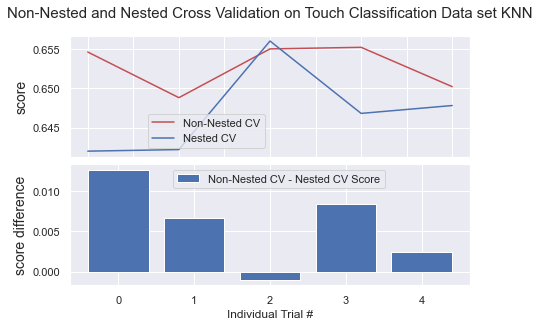

```
KNeighborsClassifier(n_neighbors=10)
```

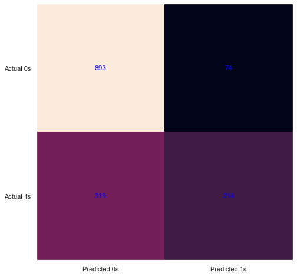

```
              precision    recall  f1-score   support

           0       0.74      0.92      0.82       967
           1       0.74      0.40      0.52       533

    accuracy                           0.74      1500
   macro avg       0.74      0.66      0.67      1500
weighted avg       0.74      0.74      0.71      1500
```

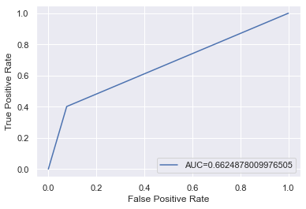

### Logit

The logit model we have here confirms some of the intuitions that we had in the explanatory phase. We find indeed that non-refundable deposits cancelation, bookings through the groups market segment and being Portugese all lead to an increase in the probability of cancelation. Still, the parameters could be biased. Also the model explains little of the variance as the R-squared is really low.

```
LogisticRegression(max_iter=1000, solver='newton-cg')
```

|  | coef |
| --- | --- |
| constante | -6.696724e-01 |
| arrival_date_week_number | -1.150528e-02 |
| arrival_date_day_of_month | -1.494973e-03 |
| stays_in_weekend_nights | 1.724778e-02 |
| stays_in_week_nights | 1.097883e-01 |
| adults | 2.809381e-01 |
| booking_changes | -4.388982e-01 |
| adr | 4.126800e-03 |
| required_car_parking_spaces | -3.531692e+00 |
| hotel_Resort Hotel | -2.516814e-01 |
| arrival_date_month_August | 1.210350e-02 |
| arrival_date_month_December | 2.137949e-01 |
| arrival_date_month_February | -4.906500e-03 |
| arrival_date_month_January | -4.197515e-01 |
| arrival_date_month_July | 1.985200e-01 |
| arrival_date_month_June | -4.270845e-02 |
| arrival_date_month_March | -5.288007e-01 |
| arrival_date_month_May | 1.943077e-03 |
| arrival_date_month_November | -1.173331e-01 |
| arrival_date_month_October | 2.576413e-01 |
| arrival_date_month_September | 4.584167e-02 |
| meal_FB | 3.548249e-02 |
| meal_HB | 1.480903e-01 |
| meal_SC | -2.565636e-02 |
| meal_Undefined | -1.117982e+00 |
| country_AGO | 1.499021e+00 |
| country_ARE | 4.292036e-01 |
| country_ARG | 4.491952e-01 |
| country_ARM | 4.822313e-10 |
| country_AUS | -1.040702e+00 |

[output cut: 114 more lines]

|  | R² | MAE | MSE | Accuracy |
| --- | --- | --- | --- | --- |
| Metric | 0.068704 | 0.213333 | 0.213333 | 0.786667 |

```
              precision    recall  f1-score   support

           0       0.79      0.91      0.85       967
           1       0.78      0.56      0.65       533

    accuracy                           0.79      1500
   macro avg       0.78      0.74      0.75      1500
weighted avg       0.79      0.79      0.78      1500
```

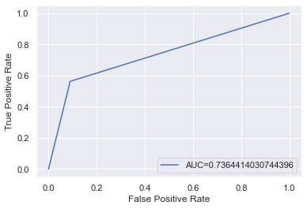

### A cross-validated decision Tree

```
Fitting 3 folds for each of 294 candidates, totalling 882 fits
Fitting 3 folds for each of 294 candidates, totalling 882 fits
Fitting 3 folds for each of 294 candidates, totalling 882 fits
Fitting 3 folds for each of 294 candidates, totalling 882 fits
Fitting 3 folds for each of 294 candidates, totalling 882 fits
Fitting 3 folds for each of 294 candidates, totalling 882 fits
Fitting 3 folds for each of 294 candidates, totalling 882 fits
Fitting 3 folds for each of 294 candidates, totalling 882 fits
Fitting 3 folds for each of 294 candidates, totalling 882 fits
Fitting 3 folds for each of 294 candidates, totalling 882 fits
Average difference of 0.006099 with std. dev. of 0.004700.
```

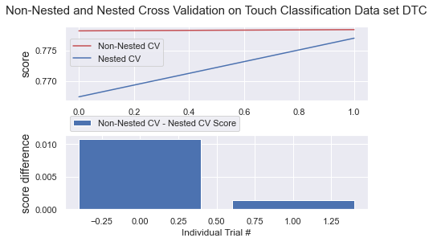

```
DecisionTreeClassifier(max_leaf_nodes=57, min_samples_split=4)
```

[figure not shown]

```
              precision    recall  f1-score   support

           0       0.83      0.91      0.87       967
           1       0.80      0.66      0.72       533

    accuracy                           0.82      1500
   macro avg       0.82      0.78      0.80      1500
weighted avg       0.82      0.82      0.82      1500
```

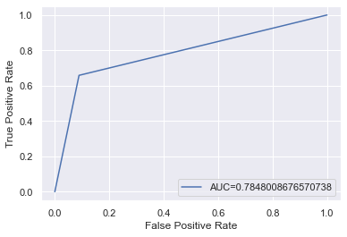

[figure not shown]

The Tree